# Tarea 1

Ortega Flores Diana

08/03/2021

Características naturales: El limón es una fruta, a su vez es un cítrico que pertenece a la familia de las rutáceas. Es conocido entre las personas por su aportación de vitamina C, lo que ayuda a prevenir enfermedades y fortalecer el sistema inmunológico, también tiene propiedades antisépticas y refrescantes. Pero sobretodo es conocido por el sabor tan peculiar que aporta a la comida además de sus indefinidas combinaciones. En cuanto a su cultivo, puede sembrarse en suelos que estén bien drenados, es posible, que este proceso se realice en un maceta hasta en terrenos con medidas mayores. Valor de uso: El limón no requiere de ningún proceso industrial para su modificación o producción, sin embargo, es parte de una gran industria. Como toda mercancía, contiene valor de uso y por ello, cubre una necesidad y en este caso es básica, es la necesidad de alimentarnos, y es utilizado en productos por sus propiedades, como cremas, mascarillas, aceites, dulces, helados, refrescos, etc. Es así que su demanda en nuestro país, así como en otros es significante. Valor de cambio: En el limón existe tanto valor de cambio como acumulación de capital, el primero, porque no necesariamente se encargan de la producción grandes empresas, ya que como vimos antes, también se puede sembrar en casa, y es algo muy común, personas que únicamente los siembran para autoconsumo y en los mercados locales, es muy común que las personas que tienen terrenos, siembren y los vendan a nivel local. Valor: El limón entra en esta categoría de valor, ya que, debido a la gran demanda del producto, se da el comercio en términos capitalistas. El limón mexicano o agrio de acuerdo con la SADER, en 2018 las exportaciones mexicanas de limón fueron de 733 miles toneladas, de las cuales, las exportaciones de limón mexicano representan el 4%, siendo su principal destino Estados Unidos.

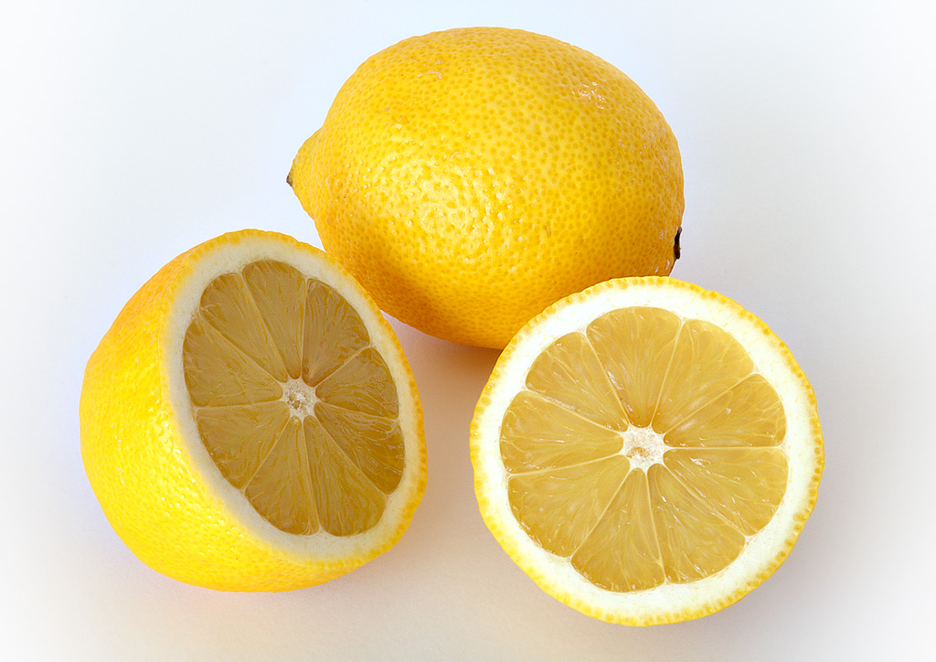

Fuente: Wikipedia

## Bibliografía

1. https://www.cima.aserca.gob.mx/work/models/cima/pdf/cadena/2019/Reporte_mercado_limon_080319.pdf
2. https://www.gob.mx/profeco/documentos/limon-mexicano-si-del-cielo-te-caen-limones?state=published